# Homework 2

Homework 2

Justin Flattery  
2022-03-10

```r
knitr::opts_chunk$set(echo = TRUE)
```

```r
library('smss')
library('alr4')
```

# 1

## 1.1.1

Predictor variable is ppdg and response variable is fertility

## 1.1.2

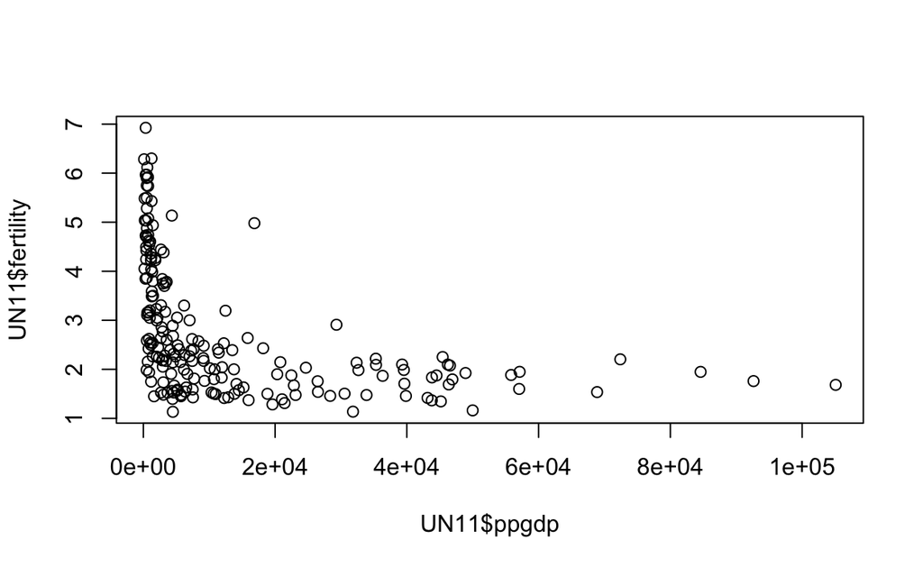

```r
plot(x = UN11$ppgdp, y = UN11$fertility)
```

A straight line mean function does not seem to be plausible for a summary of this graph. It appears to be a non linear relationship between the x and y axis.

## 1.1.3

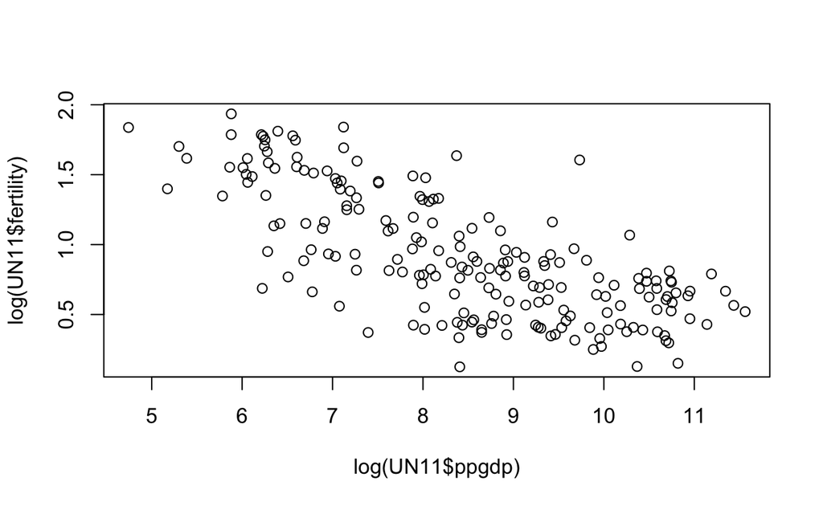

```r
plot(x = log(UN11$ppgdp), y = log(UN11$fertility))
```

Yes! There seems to be a linear relationship when using the log of these values. Therefore It appears a simple linear regression would be plausible for this graph

# 2

## a

The slope of the prediction will change by 1/1.6 (=0.625) since previously it was predicting slope based on every 1 unit changein the explanatory variable. Now the rate of that one unit is decreasing to equal the same change in the response variable

## b

The overall correlation will not change in the regression analysis since the units of the explanatory variable are all moving at an equal rate.

# 3

```r
data('water')
```

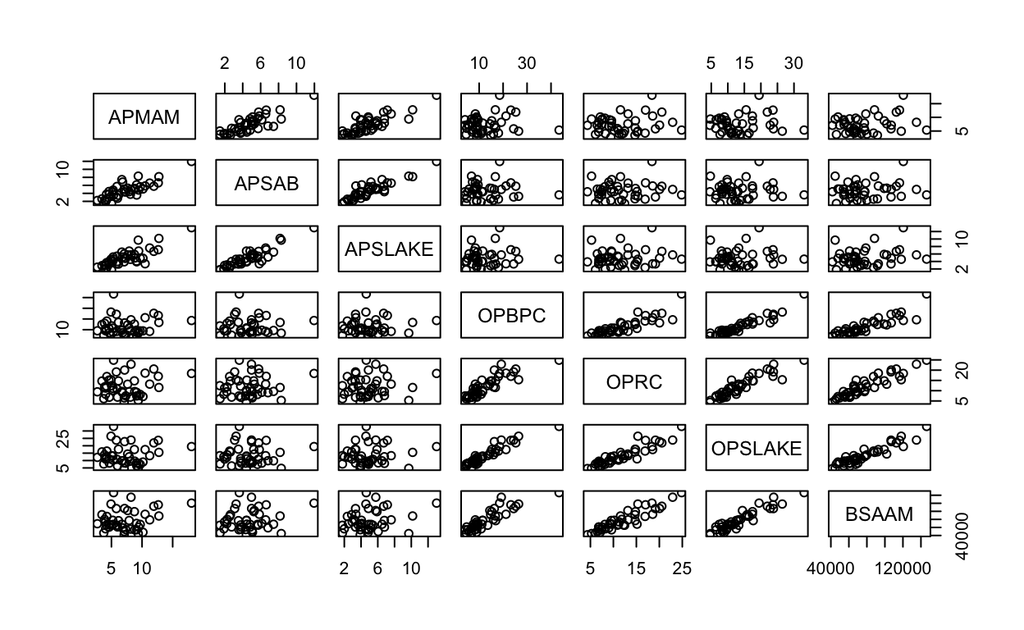

```r
pairs(~ APMAM + APSAB + APSLAKE + OPBPC + OPRC + OPSLAKE + BSAAM, data = water)
```

Using the information from these plots, we can see a linear relationship appears plausible to explain the OP sites and Bishop runoff, however the relationship for AP sites and runoff seems to be more randomly related.

# 4

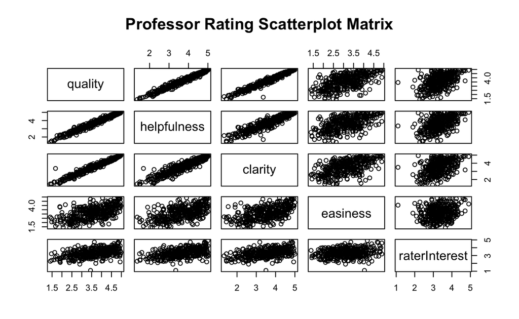

```r
data('Rateprof')

pairs(~quality+helpfulness+clarity+easiness+raterInterest,data=Rateprof,
      main="Professor Rating Scatterplot Matrix")
```

# 5

```r
data('student.survey')
```

## (a)

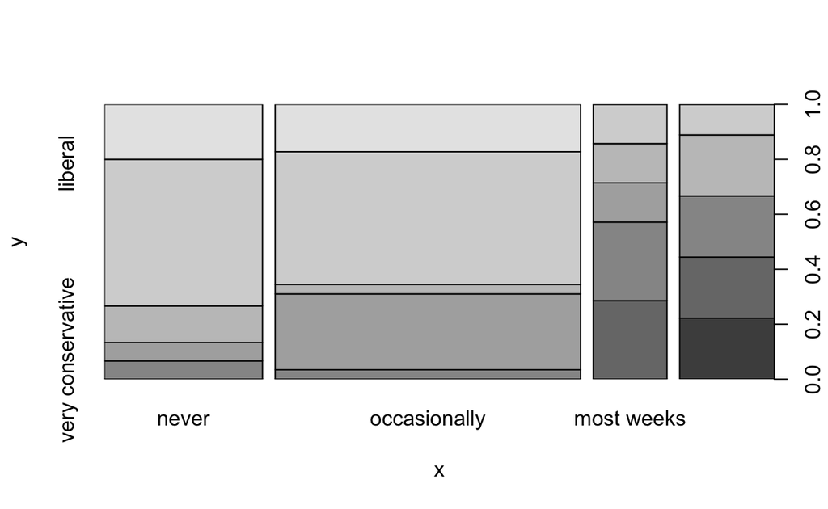

```r
plot(x = student.survey$re, y = student.survey$pi)
```

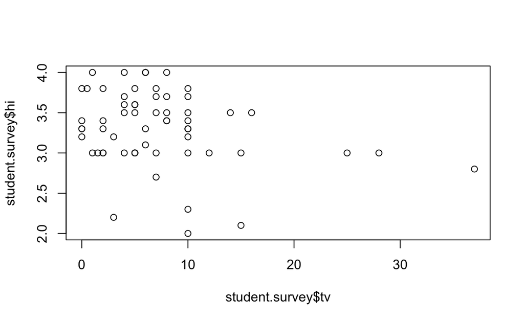

```r
plot(x = student.survey$tv, y = student.survey$hi)
```

## b)

### i)

For political ideology, there is a scale from very conservative to moderate to liberal Religiosity is measured by how often you attend a religious service It appears according to the plot in a that the more religious service attended, the more conservative individuals were.

### ii)

For high school GPA, ranked on scale from 1-4 hours of watching TV is measured by average number of hours per week that individuals watched TV It appears according to the plot in a that the more tv watched, the lower individuals GPA were.

## c)

### i)

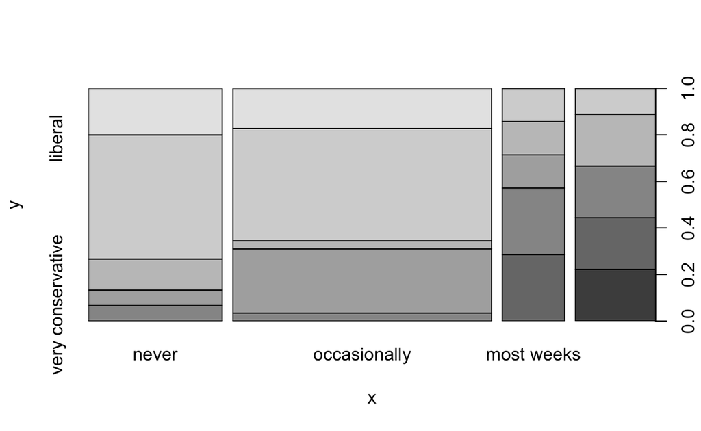

```
Number of cases in table: 60
Number of factors: 2
Test for independence of all factors:
    Chisq = 42.29, df = 18, p-value = 0.001008
    Chi-squared approximation may be incorrect
```

```r
summary(plot(x = student.survey$re, y = student.survey$pi))
```

Since this is a categorical comparison, regression can not necessarily be run (without substituing dummy variables) However, we can see the p value for this relationship is <0.01 and therefore it appears there is a significant relationship

### ii)

First, running a regression analysis

```r
lm(re ~ pi, data = student.survey)
```

```
Call:
lm(formula = re ~ pi, data = student.survey)

Coefficients:
(Intercept)         pi.L         pi.Q         pi.C         pi^4
     2.6071       2.0552       0.4501       0.1361      -0.2283
       pi^5         pi^6
    -0.3046       0.4565
```

```r
summary(lm(tv ~ hi, data = student.survey))
```

```
Call:
lm(formula = tv ~ hi, data = student.survey)

Residuals:
   Min     1Q Median     3Q    Max
-8.600 -3.790 -1.167  2.408 27.746

Coefficients:
            Estimate Std. Error t value Pr(>|t|)
(Intercept)   20.200      6.175   3.271   0.0018 **
hi            -3.909      1.849  -2.114   0.0388 *
---
Signif. codes:  0 '***' 0.001 '**' 0.01 '*' 0.05 '.' 0.1 ' ' 1

Residual standard error: 6.528 on 58 degrees of freedom
Multiple R-squared:  0.07156,   Adjusted R-squared:  0.05555
F-statistic: 4.471 on 1 and 58 DF,  p-value: 0.03879
```

I see there is a significant relationship with a low p value, however a low r2 value. However, viewing our plot, it appears a logarithmic relationship may be a better fit for this data

```r
summary(lm((tv) ~ log(hi), data = student.survey))
```

```
Call:
lm(formula = (tv) ~ log(hi), data = student.survey)

Residuals:
   Min     1Q Median     3Q    Max
-8.846 -4.035 -1.172  2.508 27.933

Coefficients:
            Estimate Std. Error t value Pr(>|t|)
(Intercept)   20.933      6.717   3.116  0.00285 **
log(hi)      -11.525      5.619  -2.051  0.04481 *
---
Signif. codes:  0 '***' 0.001 '**' 0.01 '*' 0.05 '.' 0.1 ' ' 1

Residual standard error: 6.542 on 58 degrees of freedom
Multiple R-squared:  0.06761,   Adjusted R-squared:  0.05154
F-statistic: 4.206 on 1 and 58 DF,  p-value: 0.04481
```

# 6

Since these students were the lowest performers in the previous test, they are more likely to have improved test scores closer to the mean in the next test. The findings are in line with the concept of regression toward the mean. For example, if we took the top 10 highest perfoming students and provided them tutoring, their test scores are actually expected to get closer to the mean in the next sample (i.e go down!). We could not conclude therefore that tutoring had a negative affect, similarly we do not have enough evidence with the information provided to state the tutoring program is successful.